# The influence of social-economic factors on academic performance

Viola Awor

2023-12-17

Research Question:

How do socio-economic factors, specifically parental education, lunch type, and completion of test preparation courses, influence students’ academic performance in traditional exams, and what nuanced connections can be identified between socio-economic background and educational outcomes?

Project Abstract:

This project aims to explore the impact of socio-economic factors on students’ academic performance, focusing on the StudentsPerformance dataset. Leveraging R programming, the investigation will focus on how variables such as parental education, lunch type, and completion of test preparation courses influence traditional exam scores.The research question delves into understanding the nuanced connections between socio-economic background and academic outcomes. Through statistical analyses and coding techniques in R, I aim to provide insights into educational disparities. The project adheres to a structured format, including an introduction, data description, methodology, results, and conclusion. By employing visualization tool aimed to present a comprehensive analysis.

Data Libraries

```r
library(tidyverse)
```

```r
library(dplyr)
library(tidyr)
library(ggplot2)
library(rmarkdown)
library(shiny)
library(readr)
library(knitr)
library(reshape2)
```

1. Loading student performance Dataset to read the first few rows and exploring the structure and datatype and cleaning the datset by checking for missing values if any. This Dataset doesnot have missing values

```r
csv_file_path <- "StudentsPerformance.csv"

# Read the CSV file into a data frame
Student_data <- read.csv(csv_file_path)

# Print the first few rows of the data frame
head(Student_data)
```

```
##   gender race.ethnicity parental.level.of.education        lunch
## 1 female        group B           bachelor's degree     standard
## 2 female        group C                some college     standard
## 3 female        group B             master's degree     standard
## 4   male        group A          associate's degree free/reduced
## 5   male        group C                some college     standard
## 6 female        group B          associate's degree     standard
##   test.preparation.course math.score reading.score writing.score
## 1                    none         72            72            74
## 2               completed         69            90            88
## 3                    none         90            95            93
## 4                    none         47            57            44
## 5                    none         76            78            75
## 6                    none         71            83            78
```

```r
# Exploring the dataset structure
str(Student_data)
```

```
## 'data.frame':    1000 obs. of  8 variables:
##  $ gender                     : chr  "female" "female" "female" "male" ...
##  $ race.ethnicity             : chr  "group B" "group C" "group B" "group A" ...
##  $ parental.level.of.education: chr  "bachelor's degree" "some college" "master's degree" "associate's degree" ...
##  $ lunch                      : chr  "standard" "standard" "standard" "free/reduced" ...
##  $ test.preparation.course    : chr  "none" "completed" "none" "none" ...
##  $ math.score                 : int  72 69 90 47 76 71 88 40 64 38 ...
##  $ reading.score              : int  72 90 95 57 78 83 95 43 64 60 ...
##  $ writing.score              : int  74 88 93 44 75 78 92 39 67 50 ...
```

```r
# View summary statistics and structure
summary(Student_data)
```

```
##     gender          race.ethnicity     parental.level.of.education
##  Length:1000        Length:1000        Length:1000
##  Class :character   Class :character   Class :character
##  Mode  :character   Mode  :character   Mode  :character
##
##
##
##     lunch           test.preparation.course   math.score     reading.score
##  Length:1000        Length:1000             Min.   :  0.00   Min.   : 17.00
##  Class :character   Class :character        1st Qu.: 57.00   1st Qu.: 59.00
##  Mode  :character   Mode  :character        Median : 66.00   Median : 70.00
##                                             Mean   : 66.09   Mean   : 69.17
##                                             3rd Qu.: 77.00   3rd Qu.: 79.00
##                                             Max.   :100.00   Max.   :100.00
##  writing.score
##  Min.   : 10.00
##  1st Qu.: 57.75
##  Median : 69.00
##  Mean   : 68.05
##  3rd Qu.: 79.00
##  Max.   :100.00
```

```r
# Reading the first few rows of the dataset to get understanding of the dataset
head(Student_data)
```

```
##   gender race.ethnicity parental.level.of.education        lunch
## 1 female        group B           bachelor's degree     standard
## 2 female        group C                some college     standard
## 3 female        group B             master's degree     standard
## 4   male        group A          associate's degree free/reduced
## 5   male        group C                some college     standard
## 6 female        group B          associate's degree     standard
##   test.preparation.course math.score reading.score writing.score
## 1                    none         72            72            74
## 2               completed         69            90            88
## 3                    none         90            95            93
## 4                    none         47            57            44
## 5                    none         76            78            75
## 6                    none         71            83            78
```

```r
missing_values <- Student_data %>%
  summarise_all(~ sum(is.na(.)))
```

2.Statistical analysis to understand the relationships between socio-economic factors (parental education, lunch type, test preparation course completion) and students’ performance. 1.Computed the descriptive statistics for exam scores; Math, readingand writing. Count: To know the total score for each exam. Mean:To determine the average score for each exam and performance. Standard deviation:To determine of spread from the mean of the exam scores. Minimum:To know the minimum score for exam First quartile:To know the percentange composition of exam scores in quarters 25% median:To know the score value separating the higher half from the lower half of each exam score. Third quartile:To know the percentange composition of exam scores in quarters 75% Maximum:To know the maximum score for each exam

```r
#2.Compute the discreptive statistics using dplr library

# Descriptive statistics for exam scores
# Using summarise function to compute calculate descriptive statistics: mean,Sd,min,count,median,Q1,Q3 and max values for  exam scores
describe_data <- function(column) {
  stats <- Student_data %>%
    summarise(
      Count = n(),
      Mean = mean(column, na.rm = TRUE),
      Standard_deviation = sd(column, na.rm = TRUE),
      Min = min(column, na.rm = TRUE),
      First_quartile_25th = quantile(column, 0.25, na.rm = TRUE),
      Median = median(column, na.rm = TRUE),
      Third_quartile_75th = quantile(column, 0.75, na.rm = TRUE),
      Max = max(column, na.rm = TRUE)
    )
  return(stats)
}

# Descriptive statistics for math score
math_stats <- describe_data(Student_data$math.score)
print("Math Score Statistics:")
```

```
## [1] "Math Score Statistics:"
```

```r
print(math_stats)
```

```
##   Count   Mean Standard_deviation Min First_quartile_25th Median
## 1  1000 66.089           15.16308   0                  57     66
##   Third_quartile_75th Max
## 1                  77 100
```

```r
# Descriptive statistics for reading score
reading_stats <- describe_data(Student_data$reading.score)
print("Reading Score Statistics:")
```

```
## [1] "Reading Score Statistics:"
```

```r
print(reading_stats)
```

```
##   Count   Mean Standard_deviation Min First_quartile_25th Median
## 1  1000 69.169           14.60019  17                  59     70
##   Third_quartile_75th Max
## 1                  79 100
```

```r
# Descriptive statistics for writing score
writing_stats <- describe_data(Student_data$writing.score)
print("Writing Score Statistics:")
```

```
## [1] "Writing Score Statistics:"
```

```r
print(writing_stats)
```

```
##   Count   Mean Standard_deviation Min First_quartile_25th Median
## 1  1000 68.054           15.19566  10               57.75     69
##   Third_quartile_75th Max
## 1                  79 100
```

Computing the counts of socio-economic categorical varibles to know the proportion of students according to each categorical variable

```r
# Computing counts for categorical  socio-economic variables

# Parental level of education
parental_education_counts <- table(Student_data$parental.level.of.education)

# Lunch type
lunch_type_counts <- table(Student_data$lunch)

# Test preparation course completion
test_prep_course_counts <- table(Student_data$`test.preparation.course`)

# outputting the results
print("Parental Level of Education Counts:")
```

```
## [1] "Parental Level of Education Counts:"
```

```r
print(parental_education_counts)
```

```
##
## associate's degree  bachelor's degree        high school    master's degree
##                222                118                196                 59
##       some college   some high school
##                226                179
```

```r
print("Lunch Type Counts:")
```

```
## [1] "Lunch Type Counts:"
```

```r
print(lunch_type_counts)
```

```
##
## free/reduced     standard
##          355          645
```

```r
print("Test Preparation Course Completion Counts:")
```

```
## [1] "Test Preparation Course Completion Counts:"
```

```r
print(test_prep_course_counts)
```

```
##
## completed      none
##       358       642
```

Plotting a box plotgraph to show comparison in exam score performance according to gender male and female.

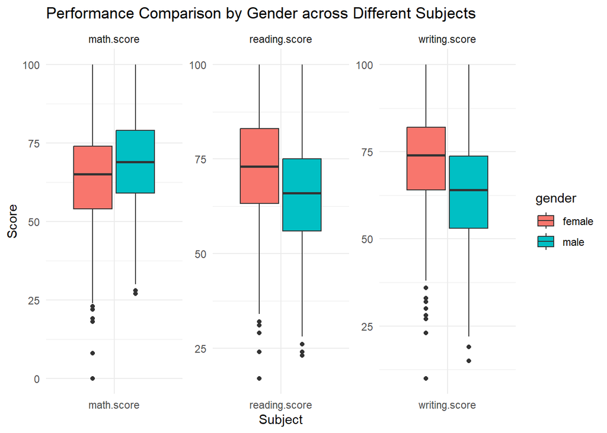

```r
#Boxplot showing comparison in performance between female and male students in exam scores.

# Reshape the data into a format  for easy plotting by ggplot2
long_data <- Student_data %>%
  gather(key = "subject", value = "score", math.score, reading.score, writing.score)

# Plotting the box plot graph
ggplot(long_data, aes(x = subject, y = score, fill = gender)) +
  geom_boxplot() +
  facet_wrap(~ subject, scales = "free") +
  labs(title = "Performance Comparison by Gender across Different Subjects",
       x = "Subject",
       y = "Score") +
  theme_minimal()
```

Plotting a grouped bar graph to show the comparison in average exam score performance according to gender

```
## No summary function supplied, defaulting to `mean_se()`
```

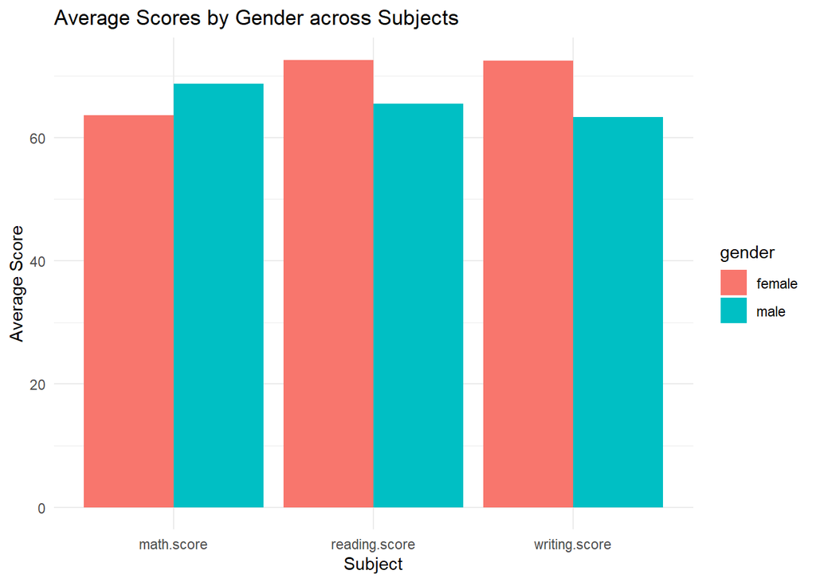

```r
#Bargraph showing average score by gender  across  subjects.
# Reshape the data for plotting
long_data <- Student_data %>%
  gather(key = "subject", value = "score", math.score, reading.score, writing.score)
# Plotting a grouped bar graph
ggplot(long_data, aes(x = subject, y = score, fill = gender)) +
  geom_bar(stat = "summary", fun.y = "mean", position = position_dodge()) +
  labs(title = "Average Scores by Gender across Subjects",
       x = "Subject",
       y = "Average Score") +
  theme_minimal()
```

A histogram showing the distribution of the spread and skewness of the scores for all students.

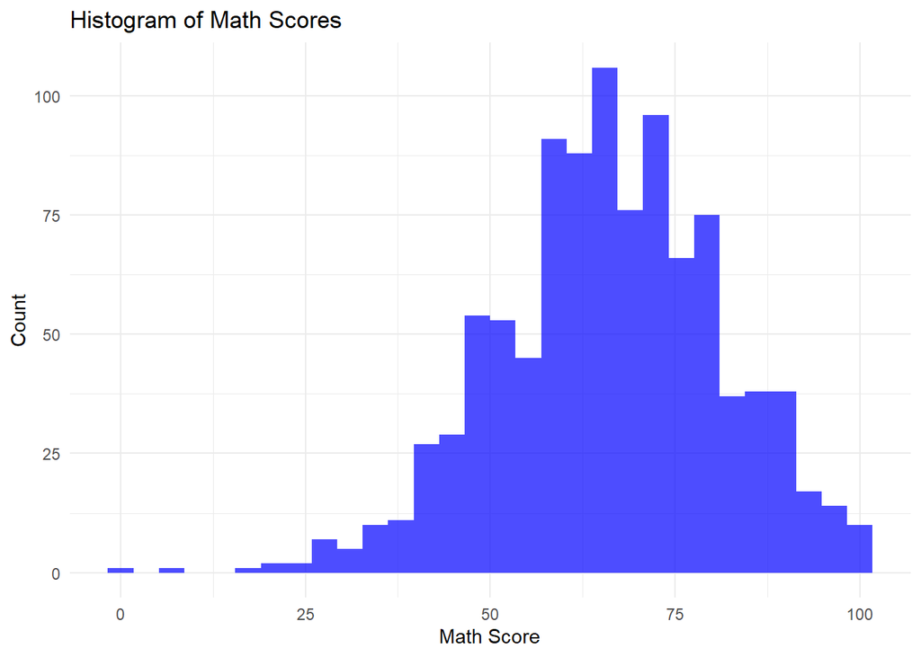

```r
# Plotting histogram for Math Scores
ggplot(Student_data, aes(x = math.score)) +
  geom_histogram(bins = 30, fill = "blue", alpha = 0.7) +
  labs(title = "Histogram of Math Scores", x = "Math Score", y = "Count") +
  theme_minimal()
```

Histogram for reading

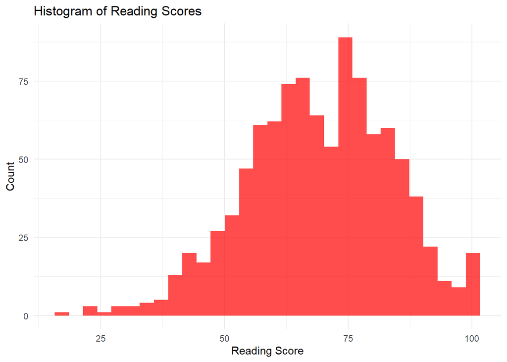

```r
# Plotting histogram for Reading Scores
ggplot(Student_data, aes(x = reading.score)) +
  geom_histogram(bins = 30, fill = "red", alpha = 0.7) +
  labs(title = "Histogram of Reading Scores", x = "Reading Score", y = "Count") +
  theme_minimal()
```

Histogram for writing

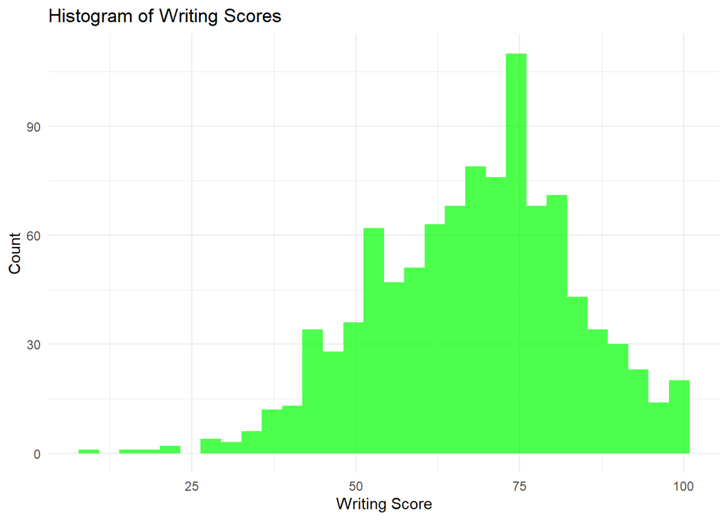

```r
# Plotting histogram for Writing Scores
ggplot(Student_data, aes(x = writing.score)) +
  geom_histogram(bins = 30, fill = "green", alpha = 0.7) +
  labs(title = "Histogram of Writing Scores", x = "Writing Score", y = "Count") +
  theme_minimal()
```

Pic chart representing proportion of students for each category of categorical variables.

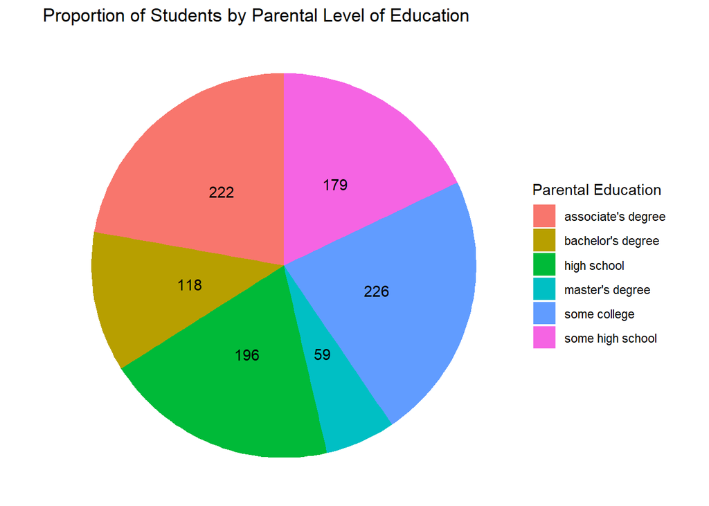

```r
# Pie Chart showing proportion of students by Parental Level of Education with count figures
Student_data %>%
  count(parental.level.of.education) %>%
  ggplot(aes(x = "", y = n, fill = parental.level.of.education)) +
  geom_bar(width = 1, stat = "identity") +
  coord_polar("y") +
  geom_text(aes(label = n), position = position_stack(vjust = 0.5)) +
  labs(title = "Proportion of Students by Parental Level of Education", fill = "Parental Education") +
  theme_void()
```

Pie Chart showing proportion of students by Lunch Types

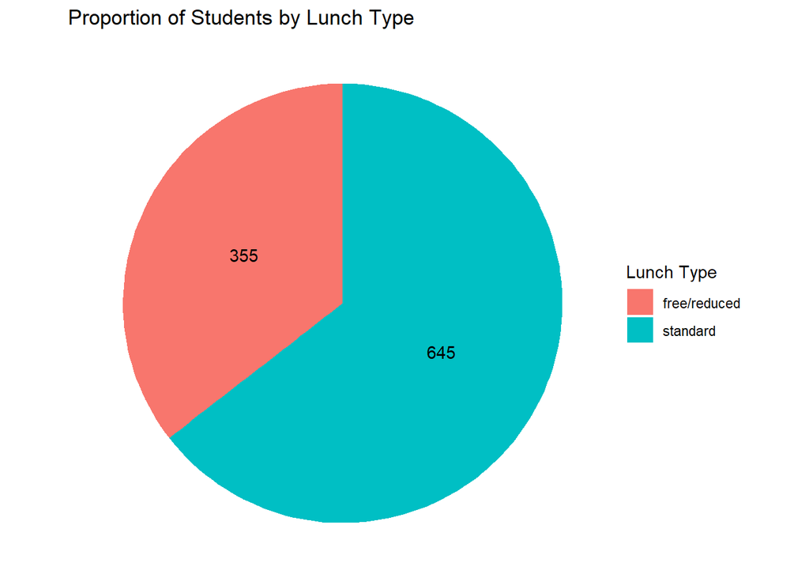

```r
# Pie Chart showing proportion of students by Lunch Types
Student_data %>%
  count(lunch) %>%
  ggplot(aes(x = "", y = n, fill = lunch)) +
  geom_bar(width = 1, stat = "identity") +
  coord_polar("y") +
  geom_text(aes(label = n), position = position_stack(vjust = 0.5)) +
  labs(title = "Proportion of Students by Lunch Type", fill = "Lunch Type") +
  theme_void()
```

Pie Chart showing proportion of students by Test Preparation Course Completion

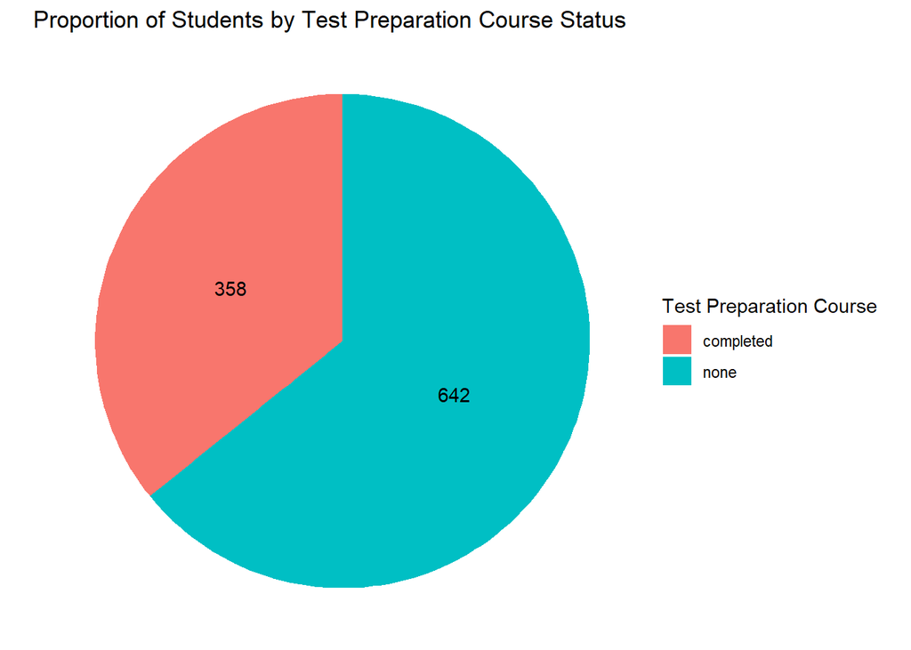

```r
# Pie Chart  showing proportion of students by Test Preparation Course Completion
Student_data %>%
  count(`test.preparation.course`) %>%
  ggplot(aes(x = "", y = n, fill = `test.preparation.course`)) +
  geom_bar(width = 1, stat = "identity") +
  coord_polar("y") +
  geom_text(aes(label = n), position = position_stack(vjust = 0.5)) +
  labs(title = "Proportion of Students by Test Preparation Course Status", fill = "Test Preparation Course") +
  theme_void()
```

Using dplyr library to Showing the distribution of scores by categorizing as (low, medium, high) across different categorical variables such as parental level of education, lunch type and test preparation course.

```r
#First, (categorize the scores into 'Low', 'Medium', and 'High')
#Then, plot stacked bar graphs for each subject score (Math, Reading, Writing) by parental level of education,test preparation course and lunch type

# Function to categorize scores <60,<80 and >=80 The categorize_score function assigns a category to each score.
categorize_score <- function(score) {
    if (score < 60) {
         "Low"
       } else if (score <= 80) {
           "Moderate"
         } else {
             "High"
           }
   }
# using  sapply  function to create new columns for categorized scores
Student_data$math_score <- sapply(Student_data$math.score, categorize_score)
Student_data$reading_score <- sapply(Student_data$reading.score, categorize_score)
Student_data$writing_score <- sapply(Student_data$writing.score, categorize_score)
```

Using the categorised distribution to Plot a stacked bar graph for Math Scores according to Parental Level of Education

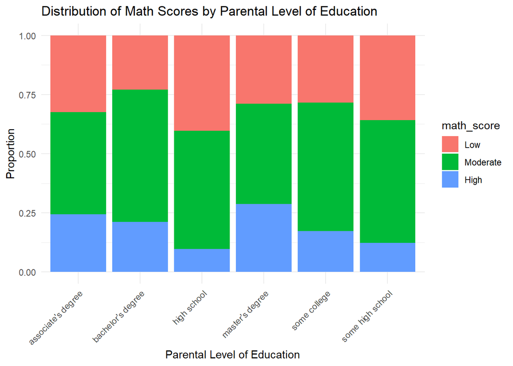

```r
Student_data$math_score <- factor(Student_data$math_score, levels = c("Low", "Moderate","High"))
   ggplot(Student_data, aes(x = parental.level.of.education, fill=math_score)) +
     geom_bar(position = "fill") +
     labs(title = "Distribution of Math Scores by Parental Level of Education",
         x = "Parental Level of Education", y = "Proportion") +
     theme_minimal() +
     theme(axis.text.x = element_text(angle = 45, hjust = 1))
```

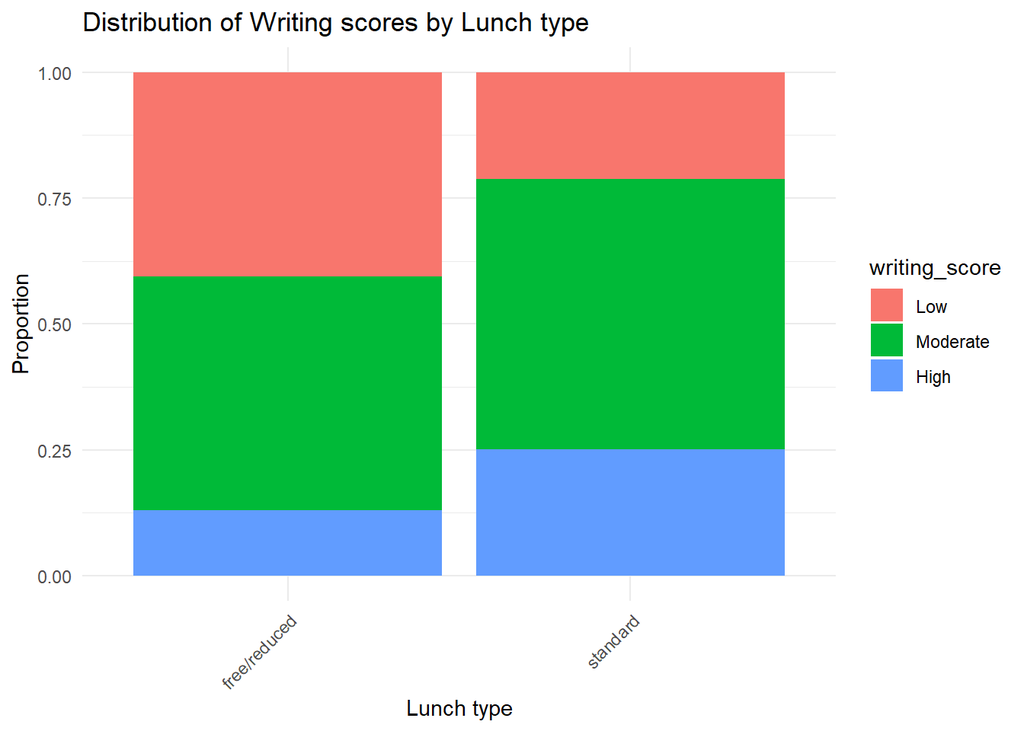

```r
  Student_data$writing_score <- factor(Student_data$writing_score, levels = c("Low", "Moderate","High"))
ggplot(Student_data, aes(x = lunch, fill=writing_score)) +
  geom_bar(position = "fill") +
  labs(title = "Distribution of Writing scores by Lunch type",
       x = "Lunch type", y = "Proportion") +
  theme_minimal() +
  theme(axis.text.x = element_text(angle = 45, hjust = 1))
```

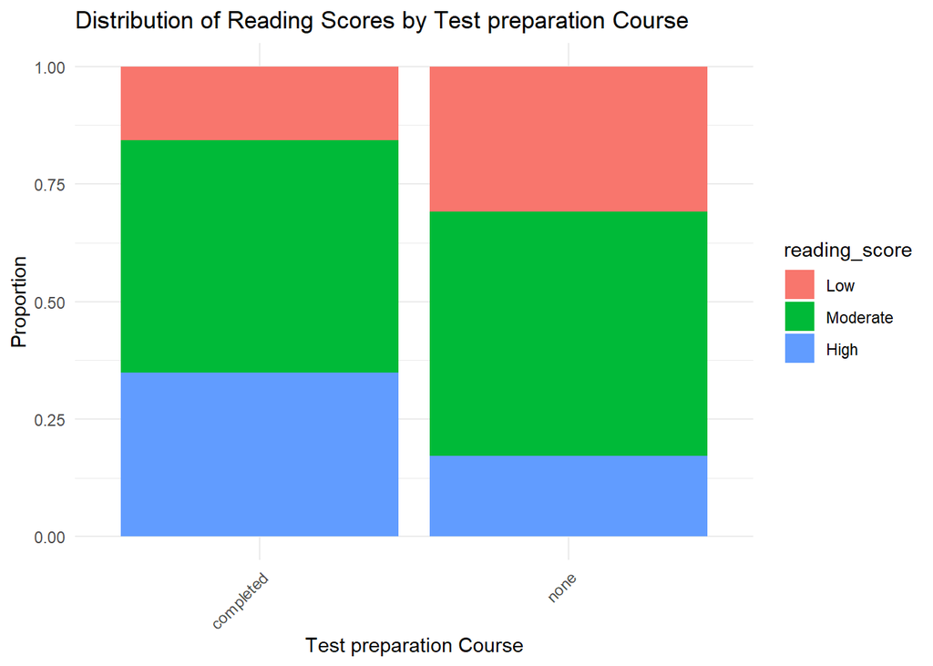

```r
Student_data$reading_score <- factor(Student_data$reading_score, levels = c("Low", "Moderate","High"))
ggplot(Student_data, aes(x = test.preparation.course , fill=reading_score)) +
  geom_bar(position = "fill") +
  labs(title = "Distribution of Reading Scores by Test preparation Course",
       x = "Test preparation Course", y = "Proportion") +
  theme_minimal() +
  theme(axis.text.x = element_text(angle = 45, hjust = 1))
```

Computing the correlation coefficients between numeric variables( Exam scores)

```r
cor_matrix <- cor(Student_data[, c("math.score", "reading.score", "writing.score")], use = "complete.obs")
#library(reshape2)  to reshape the correlation matrix into a format suitable for ggplot to plot
# Melt the data to suit the  ggplot format
melted_cor_matrix <- melt(cor_matrix)
```

Plotting a graph to visualize the correlation coeffcience of the numeric varibels.Showing a positive correlation between the exam scores starting from 0.5

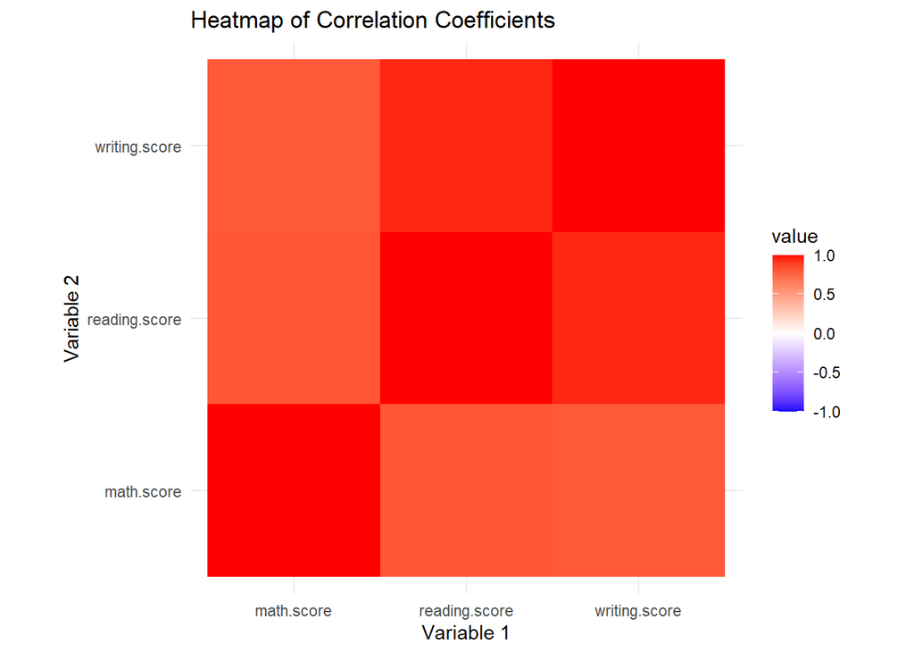

```r
# heatmap graph showing Correlation Coefficients
ggplot(melted_cor_matrix, aes(Var1, Var2, fill = value)) +
  geom_tile() +
  scale_fill_gradient2(low = "blue", high = "red", mid = "white", midpoint = 0, limit = c(-1, 1)) +
  theme_minimal() +
  labs(title = "Heatmap of Correlation Coefficients", x = "Variable 1", y = "Variable 2") +
  coord_fixed()
```

ANOVA for Parental Education Impact on Math Scores because it has more than two variables

```r
anova_result_parental_education <- aov(math.score ~ parental.level.of.education, data = Student_data)
summary(anova_result_parental_education)
```

```
##                              Df Sum Sq Mean Sq F value   Pr(>F)
## parental.level.of.education   5   7296  1459.1   6.522 5.59e-06 ***
## Residuals                   994 222394   223.7
## ---
## Signif. codes:  0 '***' 0.001 '**' 0.01 '*' 0.05 '.' 0.1 ' ' 1
```

# T-test for Lunch Type Impact on Math Scores (assuming two types of lunch)

```r
t_test_result_lunch_type <- t.test(math.score ~ lunch, data = Student_data)
summary(t_test_result_lunch_type)
```

```
##             Length Class  Mode
## statistic   1      -none- numeric
## parameter   1      -none- numeric
## p.value     1      -none- numeric
## conf.int    2      -none- numeric
## estimate    2      -none- numeric
## null.value  1      -none- numeric
## stderr      1      -none- numeric
## alternative 1      -none- character
## method      1      -none- character
## data.name   1      -none- character
```

T-test for Test Preparation Impact on Math Scores

```r
t_test_result_test_preparation <- t.test(math.score ~ test.preparation.course, data = Student_data)
summary(t_test_result_test_preparation)
```

```
##             Length Class  Mode
## statistic   1      -none- numeric
## parameter   1      -none- numeric
## p.value     1      -none- numeric
## conf.int    2      -none- numeric
## estimate    2      -none- numeric
## null.value  1      -none- numeric
## stderr      1      -none- numeric
## alternative 1      -none- character
## method      1      -none- character
## data.name   1      -none- character
```

Performing regression analysis to model the relationship between socio-economic factors and academic performance by building regression models and assessing model fit. Linear regression model for Math Score

```r
#using lm function to create the regression model.
math_model <- lm(math.score ~ parental.level.of.education + lunch + test.preparation.course, data = Student_data)
summary(math_model)
```

```
##
## Call:
## lm(formula = math.score ~ parental.level.of.education + lunch +
##     test.preparation.course, data = Student_data)
##
## Residuals:
##     Min      1Q  Median      3Q     Max
## -53.573  -9.388   0.183  10.122  35.885
##
## Coefficients:
##                                              Estimate Std. Error t value
## (Intercept)                                   64.1150     1.2294  52.153
## parental.level.of.educationbachelor's degree   1.6840     1.5610   1.079
## parental.level.of.educationhigh school        -5.1486     1.3449  -3.828
## parental.level.of.educationmaster's degree     2.7151     2.0075   1.352
## parental.level.of.educationsome college       -0.5594     1.2948  -0.432
## parental.level.of.educationsome high school   -4.8032     1.3773  -3.487
## lunchstandard                                 11.3097     0.9060  12.483
## test.preparation.coursenone                   -5.7389     0.9081  -6.319
##                                              Pr(>|t|)
## (Intercept)                                   < 2e-16 ***
## parental.level.of.educationbachelor's degree 0.280954
## parental.level.of.educationhigh school       0.000137 ***
## parental.level.of.educationmaster's degree   0.176536
## parental.level.of.educationsome college      0.665795
## parental.level.of.educationsome high school  0.000509 ***
## lunchstandard                                 < 2e-16 ***
## test.preparation.coursenone                  3.96e-10 ***
## ---
## Signif. codes:  0 '***' 0.001 '**' 0.01 '*' 0.05 '.' 0.1 ' ' 1
##
## Residual standard error: 13.7 on 992 degrees of freedom
## Multiple R-squared:  0.1894, Adjusted R-squared:  0.1837
## F-statistic: 33.12 on 7 and 992 DF,  p-value: < 2.2e-16
```

Ceating linear regression model for Reading score using ml function

```r
reading_model <- lm(reading.score ~ parental.level.of.education + lunch + test.preparation.course, data = Student_data)
summary(reading_model)
```

```
##
## Call:
## lm(formula = reading.score ~ parental.level.of.education + lunch +
##     test.preparation.course, data = Student_data)
##
## Residuals:
##     Min      1Q  Median      3Q     Max
## -41.985  -8.599   0.391   9.165  34.067
##
## Coefficients:
##                                              Estimate Std. Error t value
## (Intercept)                                   70.8293     1.2071  58.679
## parental.level.of.educationbachelor's degree   2.1104     1.5327   1.377
## parental.level.of.educationhigh school        -5.5331     1.3205  -4.190
## parental.level.of.educationmaster's degree     5.1038     1.9711   2.589
## parental.level.of.educationsome college       -1.2370     1.2713  -0.973
## parental.level.of.educationsome high school   -4.4811     1.3523  -3.314
## lunchstandard                                  7.2603     0.8896   8.162
## test.preparation.coursenone                   -7.3633     0.8917  -8.258
##                                              Pr(>|t|)
## (Intercept)                                   < 2e-16 ***
## parental.level.of.educationbachelor's degree 0.168847
## parental.level.of.educationhigh school       3.04e-05 ***
## parental.level.of.educationmaster's degree   0.009758 **
## parental.level.of.educationsome college      0.330781
## parental.level.of.educationsome high school  0.000954 ***
## lunchstandard                                9.96e-16 ***
## test.preparation.coursenone                  4.70e-16 ***
## ---
## Signif. codes:  0 '***' 0.001 '**' 0.01 '*' 0.05 '.' 0.1 ' ' 1
##
## Residual standard error: 13.45 on 992 degrees of freedom
## Multiple R-squared:  0.1571, Adjusted R-squared:  0.1512
## F-statistic: 26.42 on 7 and 992 DF,  p-value: < 2.2e-16
```

Creating linear regression model for Writing score using lm function

```r
writing_model <- lm(writing.score ~ parental.level.of.education + lunch + test.preparation.course, data = Student_data)
summary(writing_model)
```

```
##
## Call:
## lm(formula = writing.score ~ parental.level.of.education + lunch +
##     test.preparation.course, data = Student_data)
##
## Residuals:
##     Min      1Q  Median      3Q     Max
## -45.247  -8.527   0.479   9.529  32.608
##
## Coefficients:
##                                              Estimate Std. Error t value
## (Intercept)                                   70.8389     1.2024  58.915
## parental.level.of.educationbachelor's degree   3.4938     1.5268   2.288
## parental.level.of.educationhigh school        -6.5328     1.3154  -4.966
## parental.level.of.educationmaster's degree     6.5715     1.9635   3.347
## parental.level.of.educationsome college       -0.7490     1.2664  -0.591
## parental.level.of.educationsome high school   -5.6613     1.3471  -4.203
## lunchstandard                                  8.1451     0.8861   9.192
## test.preparation.coursenone                   -9.9306     0.8882 -11.181
##                                              Pr(>|t|)
## (Intercept)                                   < 2e-16 ***
## parental.level.of.educationbachelor's degree 0.022325 *
## parental.level.of.educationhigh school       8.03e-07 ***
## parental.level.of.educationmaster's degree   0.000848 ***
## parental.level.of.educationsome college      0.554366
## parental.level.of.educationsome high school  2.88e-05 ***
## lunchstandard                                 < 2e-16 ***
## test.preparation.coursenone                   < 2e-16 ***
## ---
## Signif. codes:  0 '***' 0.001 '**' 0.01 '*' 0.05 '.' 0.1 ' ' 1
##
## Residual standard error: 13.4 on 992 degrees of freedom
## Multiple R-squared:  0.2279, Adjusted R-squared:  0.2225
## F-statistic: 41.84 on 7 and 992 DF,  p-value: < 2.2e-16
```

Generating predictions of exam scores for each model using predict function

```r
math_predictions <- predict(math_model, newdata = Student_data)
reading_predictions <- predict(reading_model, newdata = Student_data)
writing_predictions <- predict(writing_model, newdata = Student_data)
```

Reshaping the dataframes to format usable by ggplot to plot the predictions above.

```r
plot_data_math <- data.frame(Actual = Student_data$math.score, Predicted = math_predictions)
plot_data_reading <- data.frame(Actual = Student_data$reading.score, Predicted = reading_predictions)
plot_data_writing <- data.frame(Actual = Student_data$writing.score, Predicted = writing_predictions)
```

Plotting a graph to show Predicted vs. Actual values for Math Scores

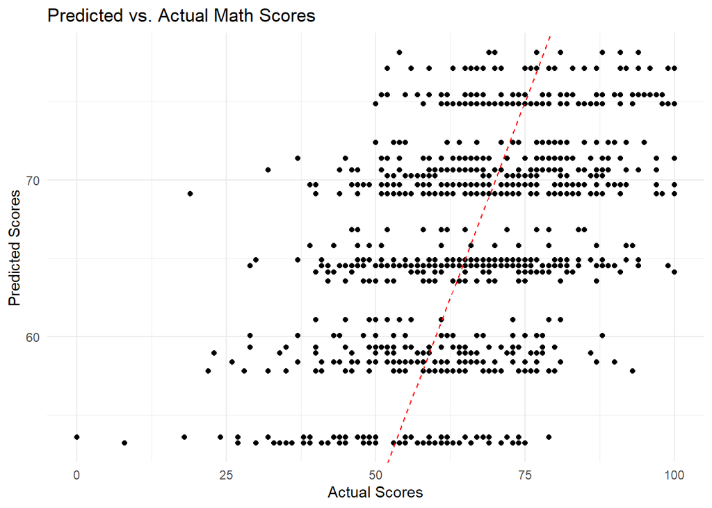

```r
ggplot(plot_data_math, aes(x = Actual, y = Predicted)) +
  geom_point() +
  geom_abline(slope = 1, intercept = 0, color = "red", linetype = "dashed") +
  labs(title = "Predicted vs. Actual Math Scores", x = "Actual Scores", y = "Predicted Scores") +
  theme_minimal()
```

Plotting Predicted vs. Actual values for reading Scores

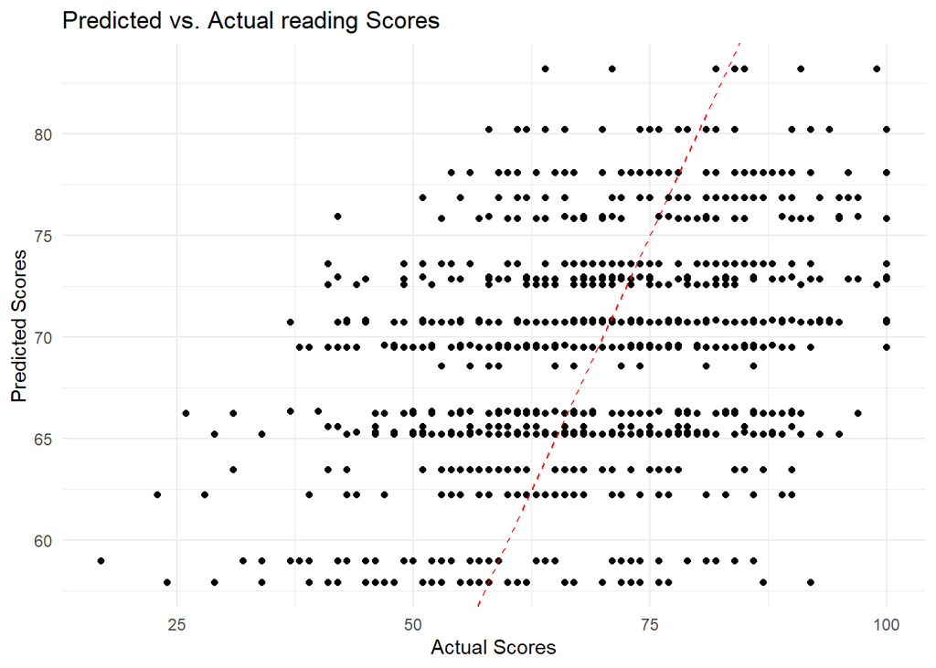

```r
ggplot(plot_data_reading, aes(x = Actual, y = Predicted)) +
  geom_point() +
  geom_abline(slope = 1, intercept = 0, color = "red", linetype = "dashed") +
  labs(title = "Predicted vs. Actual reading Scores", x = "Actual Scores", y = "Predicted Scores") +
  theme_minimal()
```

Plotting Predicted vs. Actual values for writing Scores

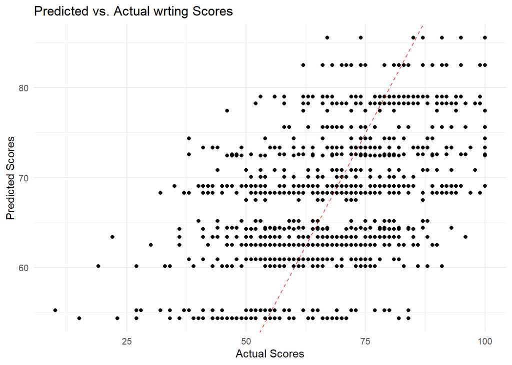

```r
ggplot(plot_data_writing, aes(x = Actual, y = Predicted)) +
  geom_point() +
  geom_abline(slope = 1, intercept = 0, color = "red", linetype = "dashed") +
  labs(title = "Predicted vs. Actual wrting Scores", x = "Actual Scores", y = "Predicted Scores") +
  theme_minimal()
```

Coefficient plot for Math Model

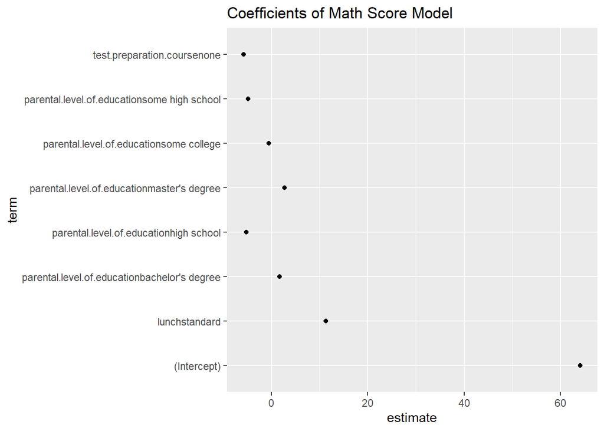

```r
coef_data <- broom::tidy(math_model)
ggplot(coef_data, aes(estimate, term)) +
  geom_point() +
  labs(title = "Coefficients of Math Score Model")
```

Coefficient plot for reading Model

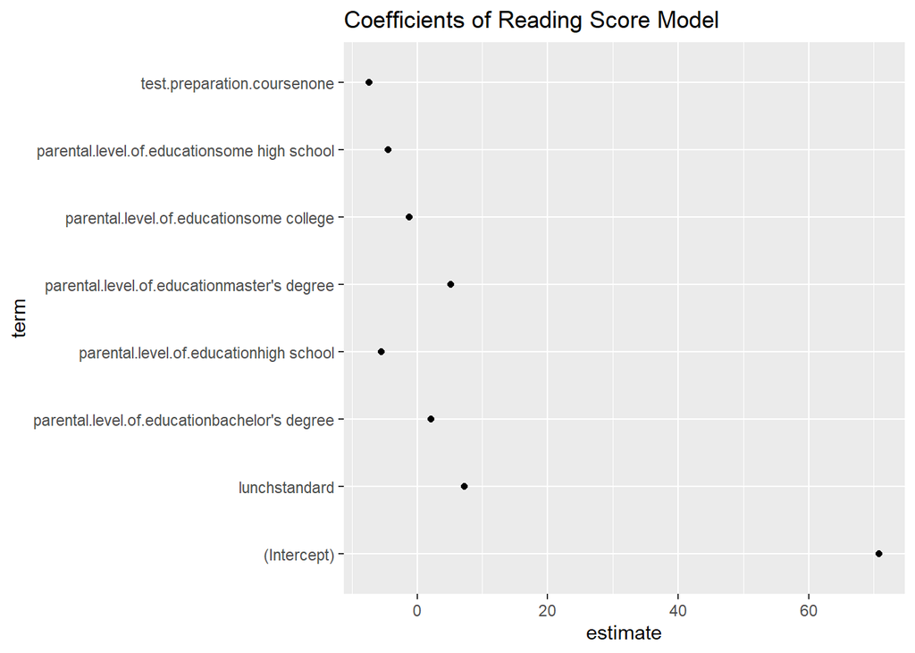

```r
coef_data <- broom::tidy(reading_model)
ggplot(coef_data, aes(estimate, term)) +
  geom_point() +
  labs(title = "Coefficients of Reading Score Model")
```

Coefficient plot for writing Model

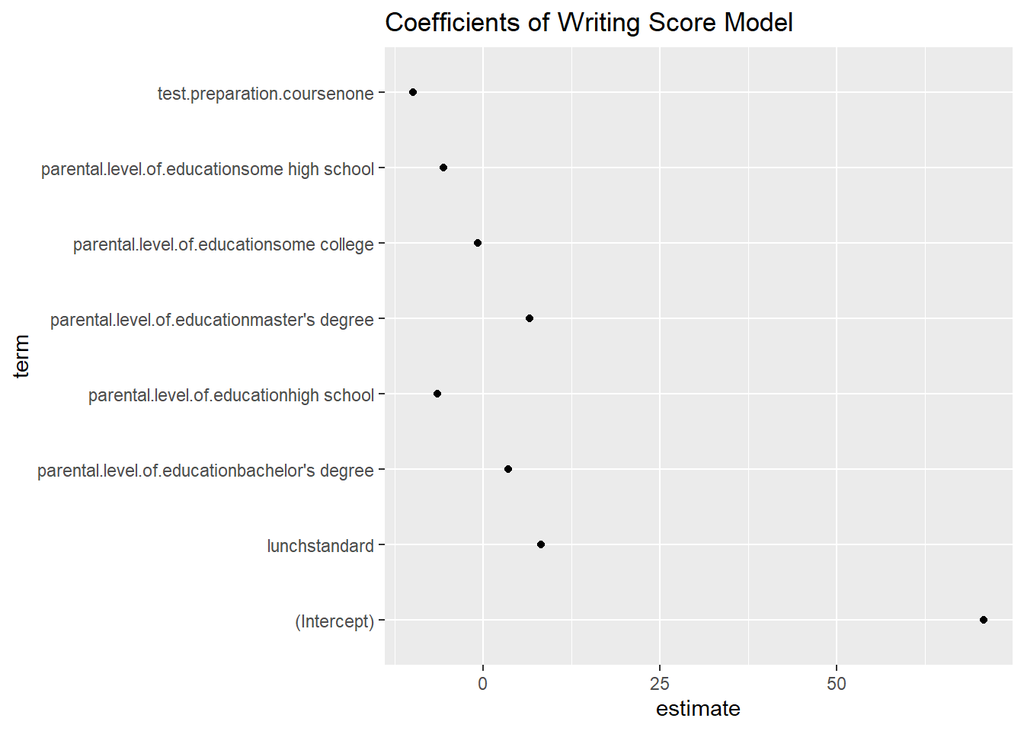

```r
#Using broom and tidy functions to transform thestatistical test into tidy datafram usable by ggplot
coef_data <- broom::tidy(writing_model)
ggplot(coef_data, aes(estimate, term)) +
  geom_point() +
  labs(title = "Coefficients of Writing Score Model")
```

Residual plot for the math model

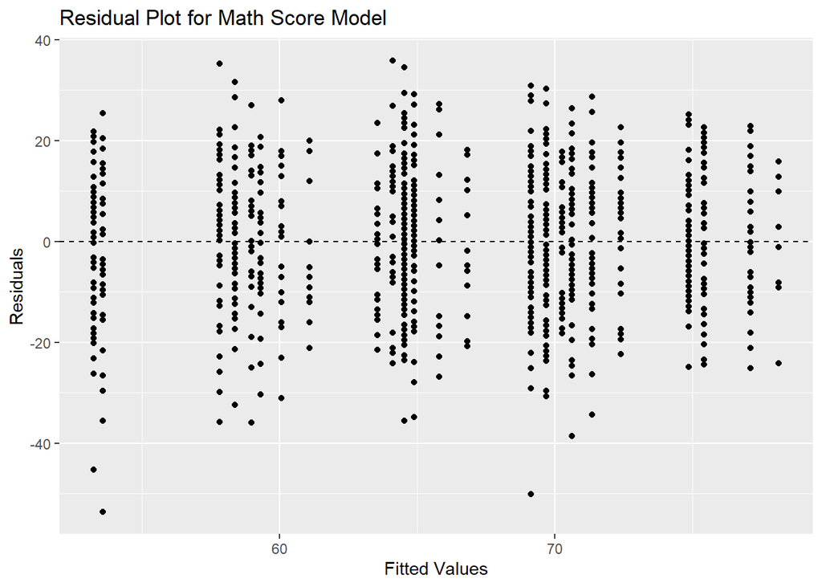

```r
#Initialize the object
ggplot(math_model, aes(.fitted, .resid)) +# set mapping for the plot getting difference between the predicted values and residual value
  geom_point() +
  geom_hline(yintercept = 0, linetype = "dashed") +
  labs(title = "Residual Plot for Math Score Model", x = "Fitted Values", y = "Residuals")
```

Residual Plot for Reading Model

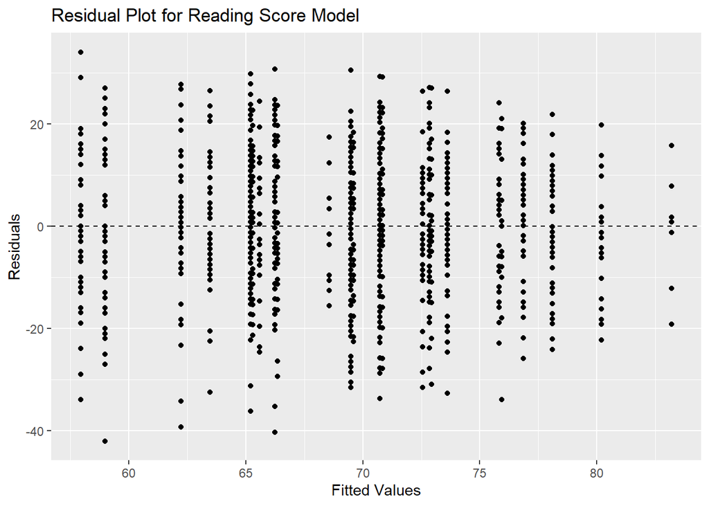

```r
ggplot(reading_model, aes(.fitted, .resid)) + #set mapping for the plotgetting difference between the predicted values and residual value
  geom_point() +
  geom_hline(yintercept = 0, linetype = "dashed") +
  labs(title = "Residual Plot for Reading Score Model", x = "Fitted Values", y = "Residuals")
```

Residual Plot for Writing Model

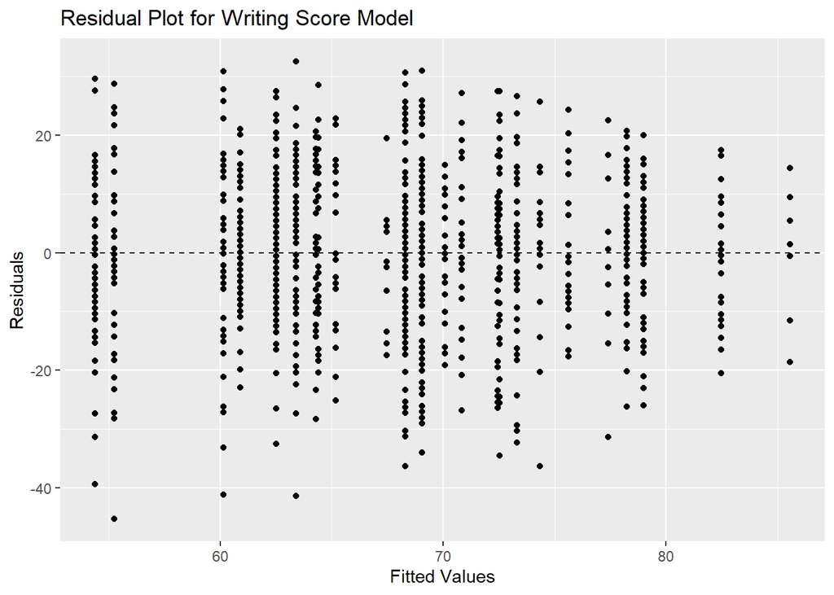

```r
ggplot(writing_model, aes(.fitted, .resid)) + # set mapping for the plot,getting difference between the predicted values and residual value
  geom_point() +
  geom_hline(yintercept = 0, linetype = "dashed") +
  labs(title = "Residual Plot for Writing Score Model", x = "Fitted Values", y = "Residuals")
```

Box plot Impact of Parental level of education on math score

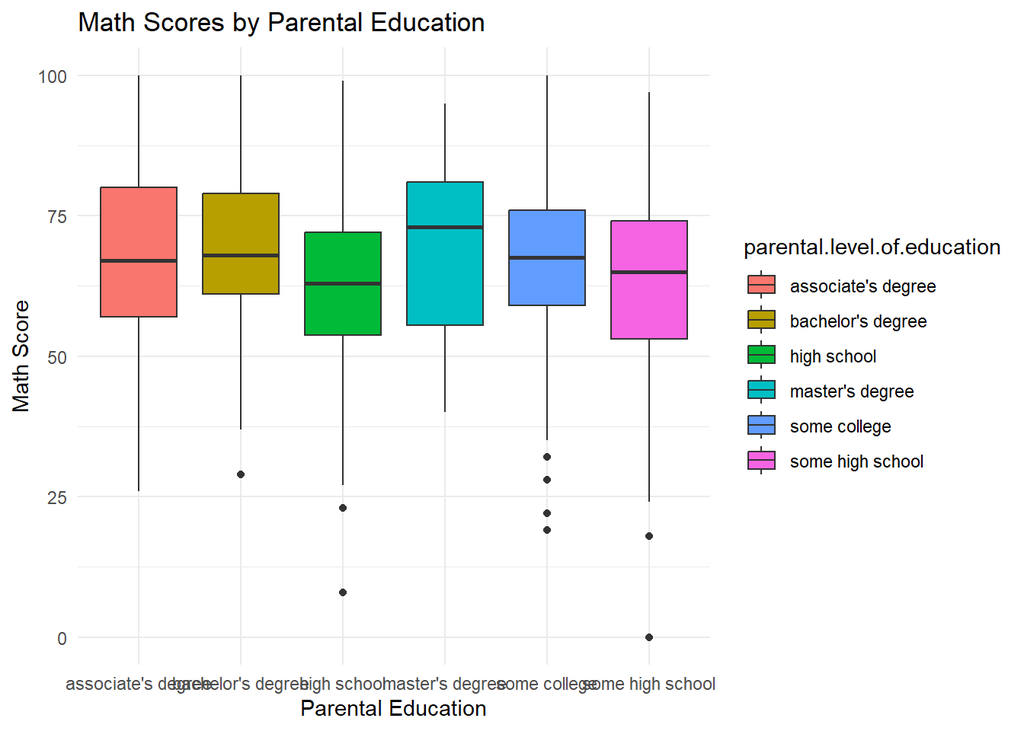

```r
ggplot(Student_data, aes(x = parental.level.of.education, y = math.score, fill = parental.level.of.education)) +
  geom_boxplot() +
  labs(title = "Math Scores by Parental Education", x = "Parental Education", y = "Math Score") +
  theme_minimal()
```

Box plot showing Impact of Parental level of education on Reading score

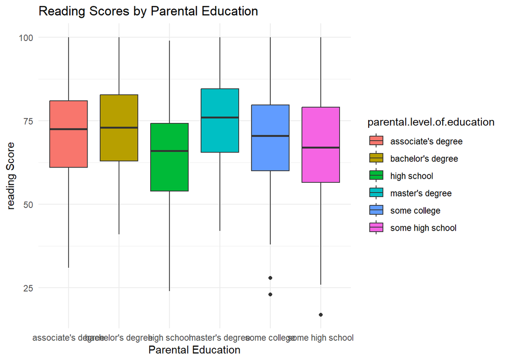

```r
ggplot(Student_data, aes(x = parental.level.of.education, y = reading.score, fill = parental.level.of.education)) +
  geom_boxplot() +
  labs(title = "Reading Scores by Parental Education", x = "Parental Education", y = "reading Score") +
  theme_minimal()
```

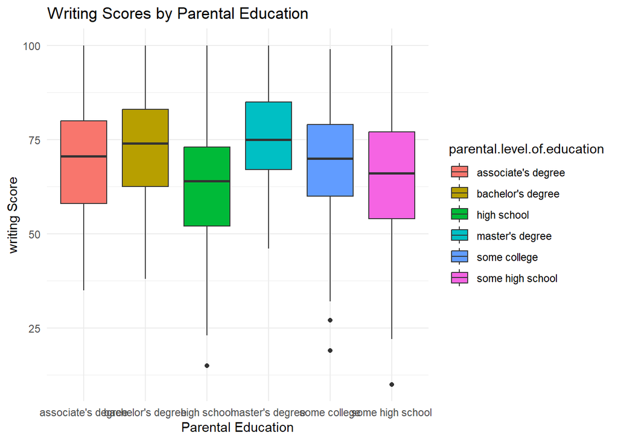

```r
ggplot(Student_data, aes(x = parental.level.of.education, y = writing.score, fill = parental.level.of.education)) +
  geom_boxplot() +
  labs(title = "Writing Scores by Parental Education", x = "Parental Education", y = "writing Score") +
  theme_minimal()
```

Box plot showing Impact of lunch type on math score

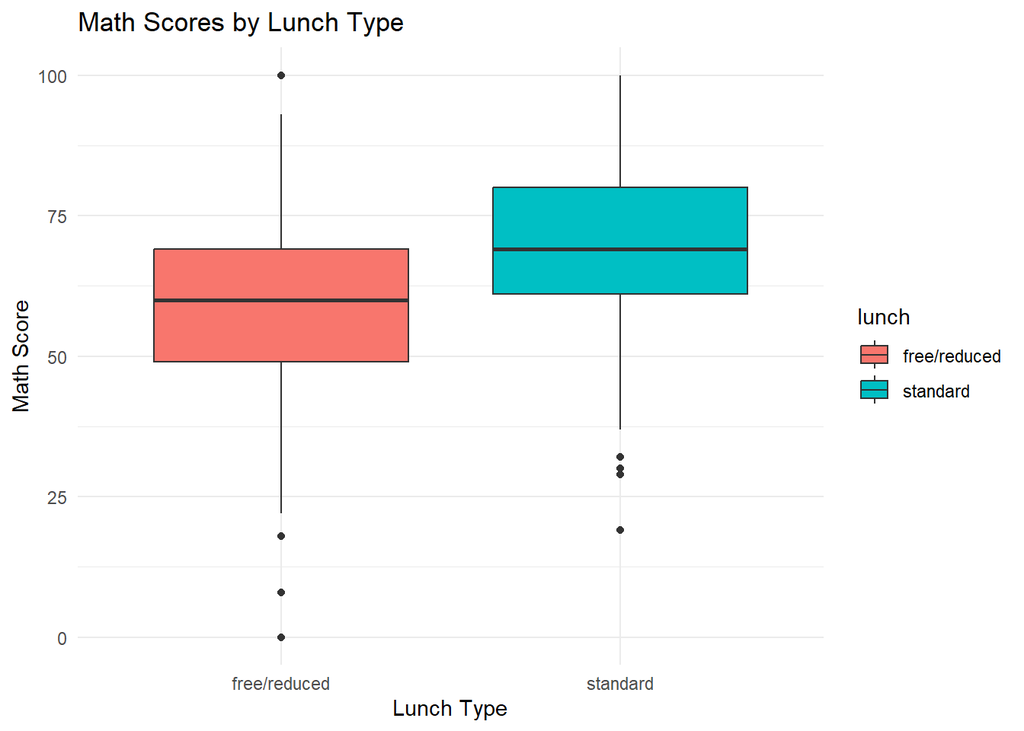

```r
# Box plot showing Impact of  lunch type on  math score
ggplot(Student_data, aes(x = lunch, y = math.score, fill = lunch)) +
  geom_boxplot() +
  labs(title = "Math Scores by Lunch Type", x = "Lunch Type", y = "Math Score") +
  theme_minimal()
```

Box plot showing Impact of lunch type on Reading score

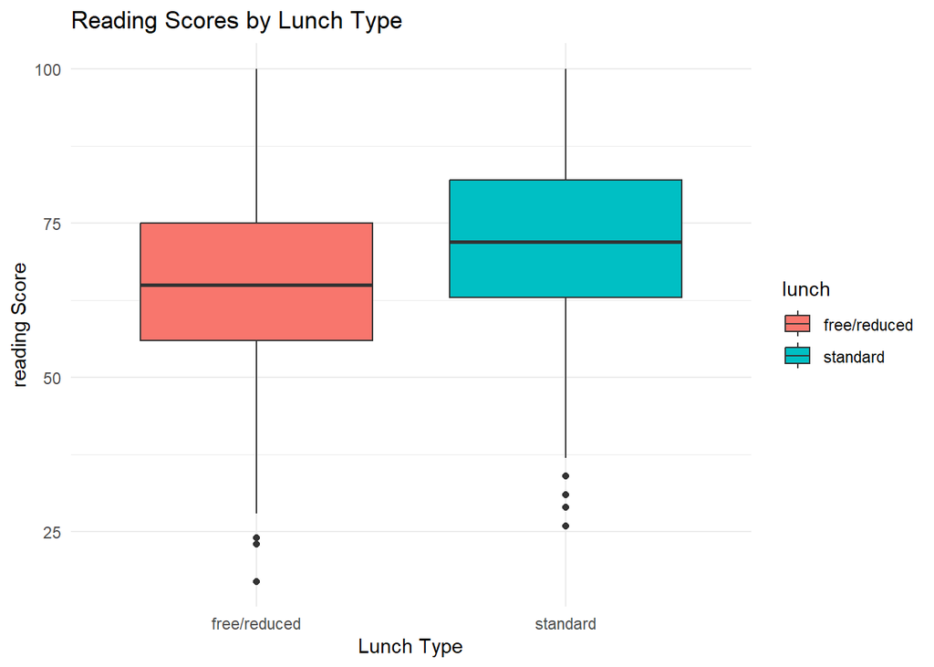

```r
#Box plotBox plot showing Impact of  lunch type on  reading score
ggplot(Student_data, aes(x = lunch, y = reading.score, fill = lunch)) +
  geom_boxplot() +
  labs(title = "Reading Scores by Lunch Type", x = "Lunch Type", y = "reading Score") +
  theme_minimal()
```

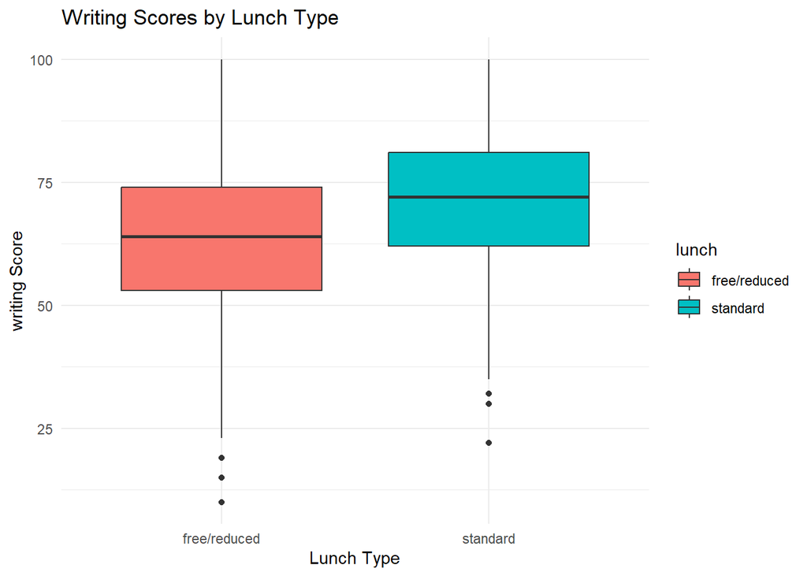

```r
# Box plot Box plot showing Impact of  lunch type on  writing score
ggplot(Student_data, aes(x = lunch, y = writing.score, fill = lunch)) +
  geom_boxplot() +
  labs(title = "Writing Scores by Lunch Type", x = "Lunch Type", y = "writing Score") +
  theme_minimal()
```

Test preparation Course Box plot showing the impact of test preparation course on math score

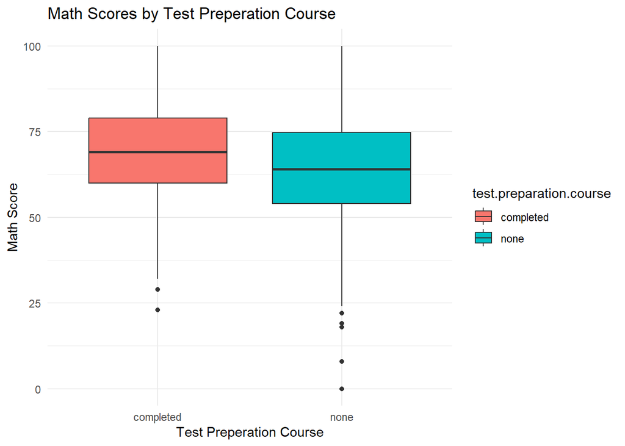

```r
ggplot(Student_data, aes(x = test.preparation.course, y = math.score, fill = test.preparation.course)) +
  geom_boxplot() +
  labs(title = "Math Scores by Test Preperation Course", x = "Test Preperation Course", y = "Math Score") +
  theme_minimal()
```

Box plot showing the impact of test preparation course on reading score

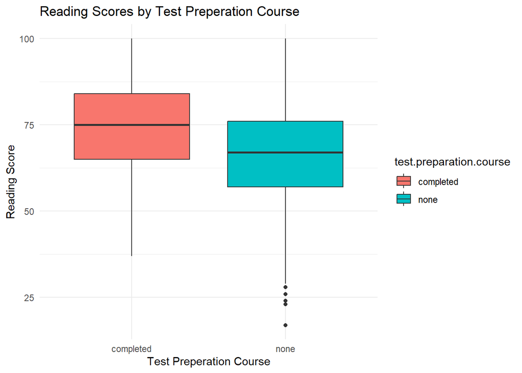

```r
ggplot(Student_data, aes(x = test.preparation.course, y = reading.score, fill = test.preparation.course)) +
  geom_boxplot() +
  labs(title = "Reading Scores by Test Preperation Course", x = "Test Preperation Course", y = "Reading Score") +
  theme_minimal()
```

Box plot showing the impact of test preparation course on writing score

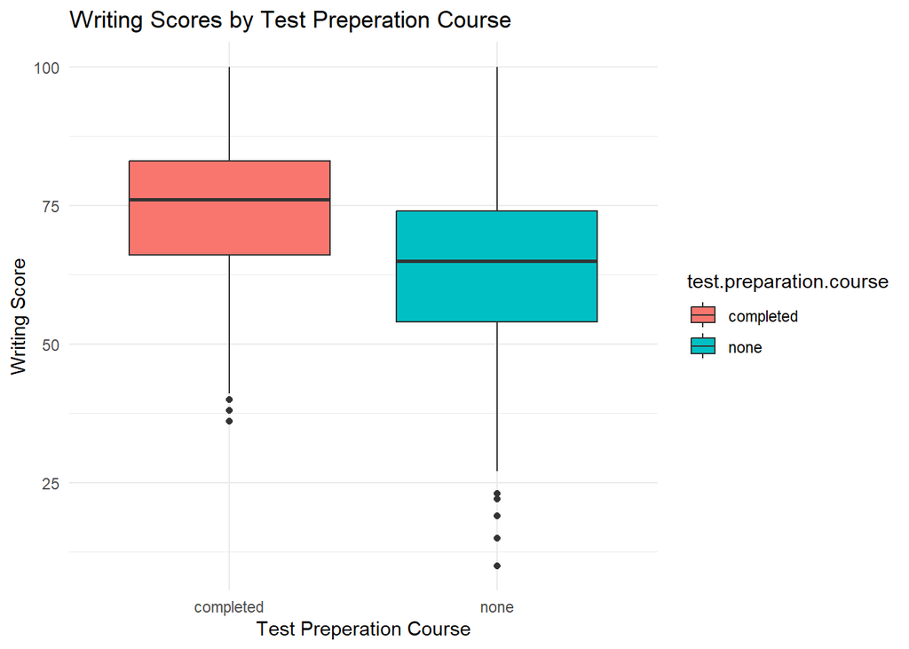

```r
ggplot(Student_data, aes(x = test.preparation.course, y = writing.score, fill = test.preparation.course)) +
  geom_boxplot() +
  labs(title = "Writing Scores by Test Preperation Course", x = "Test Preperation Course", y = "Writing Score") +
  theme_minimal()
```